# Data dictionary

Barde Julien, Andriamasinoro Herinomena

2023-01-25

# 1 Introduction

This report describes the data dictionary of the “fish” database. The content is taken from the following google spreadsheets :

- [List of colums for all schemas](https://docs.google.com/spreadsheets/d/1V4XlsKNpm7I4Ya2vEjdZE7I6GQBmfzo7STJB0LxUmiA/edit#gid=864330671)
- [List of colums for all tables](https://docs.google.com/spreadsheets/d/1V4XlsKNpm7I4Ya2vEjdZE7I6GQBmfzo7STJB0LxUmiA/edit#gid=1542923561)
- [List of colums for all columns](https://docs.google.com/spreadsheets/d/1V4XlsKNpm7I4Ya2vEjdZE7I6GQBmfzo7STJB0LxUmiA/edit#gid=1136675083)

The content of the data dictionnary can be improved by editing the google spreadsheets.

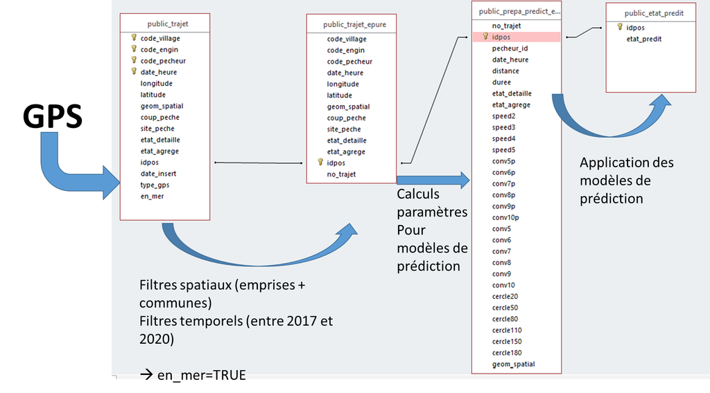

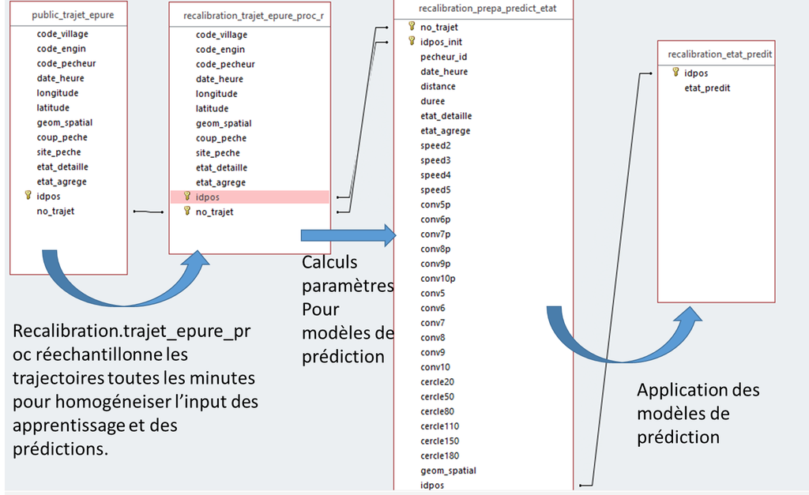

# 2 The schemas

Here is the list and definition of schemas in the database

Description of schemas

schema

description

public

Le schéma “public” regroupe les données de GPS qui sont stockées dans plusieurs tables reliées par des clés (explicites) ou des positions dans le temps ou dans l’espace (implicites). Des équipements GPS ont été mis en place sur un échantillon d’une centaine de pirogues et donnent la position de ces bateaux à une fréquence de temps hétérogène (entre 30 secondes et 1,5 minutes). Les positions GPS stockées sont ensuite transformées en trajectoires. Les trajectoires sont ensuite traitées par des modèles pour prédire la positions des opérations de pêche. Les modèles de prédiction nécesite un jeu de données d’apprentissage composé de données brutes et de données observées. Un modèle par type d’engin sera créé et ce modèle servira ensuite à prédire les actions de pêche (sans observations).

recalibration

Le schema “recalibration” regroupe les mêmes tables que le schema “public” mais les données GPS brutes ont été transformées (recalibrées) pour ré-exprimer toutes les positions avec la même fréquence de temps (paramètre fixé à une minute actuellement). Cet alignement sur la même fréquence a été réalisé avec des packages R.

suivi

Le schema “suivi” regroupe des tables complémentaires à celles qui stockent les données des GPS (dans les schemas “public” et “recalibration”). Ces tables stockent les données halieutiques relatives au suivi des captures effectuées par les pirogues équipées de GPS : données sur les pêcheurs, les captures (par un système de suivi participatif) et des échantillons de captures au débarquement.

Ces données sont d’abord collectées sur le terrain avec des fiches papier qui sont ensuite saisies dans une base Access pour la baie de Tuléar (ou dans des fichiers Excel pour la baie de Ranobe). Les tables Access ou Excel (station, poids, espèce..) sont ensuite transférées à l’identique dans le schéma “suivi” de la base Postgres avec des scripts R. Modèle de la base Access créé par Faustinato. Fichiers Excel de Sandra.

Le suivi participatif permet de récuperer les productions déclarées par grand groupes d’espèces sur 12 mois (à partir des captures journalières des pêcheurs équipés de GPS) et le le suivi des débarquements permet de mesurer la biodiversité des captures.

- des données de captures par sortie (collectées à partir de fiches papiers par des observateurs embarqués),
- des données de compositions de captures (collectées à partir de fiches papiers au débarquement ??)
- des photos des espèces qui seront ensuite traitées pour automatiser les mesures de tailles et les identifications. Les photos ne sont pas stockées dans la base de données qui stocke uniquement un identifiant pour les retrouver facilement sur un autre système de stockage (elles pourront être stockées ailleurs : NAS, serveur http..).

Le lien entre les tables de captures et la table de positions GPS prédites se fait par le couple date-code pêcheur. Pour certains couples des tables de captures, il y a un doublon correspondant à 2 sorties le même jour, qui sont reliées aux 2 trajets correspondants dans l’ordre chronologique. A noter que dans certains cas, il n’y a pas de trajet GPS associé au couple date-code pêcheur (le pêcheur a oublié le GPS chez lui…).

ref

Le schema “ref” regroupe les référentiels (non spatialisés) qui sont utilisés pour contrôler les valeurs des colonnes dans différentes tables de la base

geo

Le schema “geo” regroupe les référentiels spatialisés ou référentiels spatiaux qui correspondent à des couches vecteurs (shapefiles…) qui ont été importées dans la base. Les shapefiles importés dans PostGIS ont été créés avec QGIS à partir d’images satellites (à la main ou traitements d’images ??). On y trouve des couches vecteurs sur les “Mangroves”, “Terrasses peu profondes”, “Lagons”, “Récifs”, zones du “Large” et zones à “Terre”.

historique

Le schéma historique regroupe les données collectées en 2009 sur la même Baie de Tulear (cf Henrich Bruggemann)

svg

Le schema svg est un schema de backup lors d’updates sur les données

# 3 The tables

Description of tables

[output not shown]

# 4 The columns

Description of columns

schema

table

column

description

public

etat_predit

idpos

Identifiant numérique séquentiel (auto-incrémenté) qui donne le numéro du point GPS à l’intérieur d’une trajectoire

public

etat_predit

etat_predit

Indique si le point GPS est prédit en pêche ou non

public

trajet

code_village

Code du village dans lequel se trouve la pirogue du pêcheur suivi

public

trajet

code_engin

Code de l’engin utilisé par la pirogue du pêcheur suivi

public

trajet

code_pecheur

Code du pêcheur suivi

public

trajet

date_heure

Date et heure (timestamp) donné par le GPS, en UTC

public

trajet

longitude

Longitude du point GPS

public

trajet

latitude

Latitude du point GPS

public

trajet

geom_spatial

Géométrie, type de données spatial, créée à partir de la latitude et de la longitude

public

trajet

coup_peche

Information du numero du coup de pêche venant des observations

public

trajet

site_peche

site de pêche déclaré par les pêcheurs (indiqué par un topoyme)

public

trajet

etat_detaille

Observations réalisées à bord par des observateurs embarqués pour indiquer l’activité / opération de pêche (mais pas toujours de bonne qualité et moins fiable qu’avec QGIS). Cette colonne décrit la nature de l’activité de pêche : “pose_filet”, “NA”, “Collecte_captue”, “Recherche_bon_endroit”, “Pose_filet”, “remonter_filet”, “trait_de_la senne”, “peche_au_fustilaridae”, “route_village”, “Volie_bas”, “Attente_avant_pose_filet”, “collecte_captures”, “recuperation_senne”, “depart”, “decrochage_senne_sur_coraux”, “retour”, “Attenta_avant_pose_filet”, “Remonter_filet”, “Action_peche”, “voile_bas”, “Retour”, “Depart”, “recherche_du_bon_endroit”, “Autre_technique”, “pose_senne”, “rabattage_poisson”, “dpirogue_desencree”, “action_peche”, “Rabatage_poissons”, “Collecte_capture”,“actions_peche”, “Tirer_filet”, “Voile_haut”, “deplacement_vers_autre_site”, “recherche_bon_endroit”, “Remonter_filet_collecte”, “trait _senne “,”Recherche_bon__endroit “,”route_site “,”Voile_bas”, “Voile-bas”, “Rabattage_poisson”, “remontee_senne”, “voile_haut”, “attente_avant_pose_senne”, “Deplacement_autre_site”, “volie_haut”, “deplacement_autre_site”, “departe”, “trait_senne”

public

trajet

etat_agrege

Ce sont des données d’observation produits sur QGIS par Roddy qui indique si le point GPS est a priori en pêche ou pas. Ces sont les données d’entraînement nécessaires pour le modèle de prédiction. Cette colonne décrit si le point est en pêche ou non : “Non_peche”, “non_peche”, “peche”, “Peche”, “Preparation”

public

trajet

idpos

Identifiant numérique séquentiel (auto-incrémenté) qui donne le numéro du point GPS à l’intérieur d’une trajectoire

public

trajet

date_insert

Date du jour de l’importation des données

public

trajet

type_gps

Type (modèle) du GPS utilisé pour suivre la trajectoire des pirogues : catlog ou IG

public

trajet

en_mer

booléen qui indique si le point est en mer et dans notre zone d’étude (appartient à la zone décrite dans la table geo.emprise) et en mer (en dehors de la zone definie dans la table geo.communes_uni)

public

trajet_epure

code_village

Code du village dans lequel se trouve la pirogue du pêcheur suivi

public

trajet_epure

code_engin

Code de l’engin utilisé par la pirogue du pêcheur suivi

public

trajet_epure

code_pecheur

Code du pêcheur suivi

public

trajet_epure

date_heure

Date et heure (timestamp) donné par le GPS, en UTC

public

trajet_epure

longitude

Longitude du point GPS

public

trajet_epure

latitude

Latitude du point GPS

public

trajet_epure

geom_spatial

Géométrie, type de données spatial, créée à partir de la latitude et de la longitude

public

trajet_epure

coup_peche

Information du numero du coup de pêche venant des observations

public

trajet_epure

site_peche

site de pêche déclaré par les pêcheurs (indiqué par un topoyme)

public

trajet_epure

etat_detaille

Observations à bord pour indiquer l’activité / opération de pêche (mais pas toujours de bonne qualité et moins fiable qu’avec QGIS). Cette colonne décrit la nature de l’activité de pêche : “pose_filet”, “NA”, “Collecte_captue”, “Recherche_bon_endroit”, “Pose_filet”, “remonter_filet”, “trait_de_la senne”, “peche_au_fustilaridae”, “route_village”, “Volie_bas”, “Attente_avant_pose_filet”, “collecte_captures”, “recuperation_senne”, “depart”, “decrochage_senne_sur_coraux”, “retour”, “Attenta_avant_pose_filet”, “Remonter_filet”, “Action_peche”, “voile_bas”, “Retour”, “Depart”, “recherche_du_bon_endroit”, “Autre_technique”, “pose_senne”, “rabattage_poisson”, “dpirogue_desencree”, “action_peche”, “Rabatage_poissons”, “Collecte_capture”,“actions_peche”, “Tirer_filet”, “Voile_haut”, “deplacement_vers_autre_site”, “recherche_bon_endroit”, “Remonter_filet_collecte”, “trait _senne “,”Recherche_bon__endroit “,”route_site “,”Voile_bas”, “Voile-bas”, “Rabattage_poisson”, “remontee_senne”, “voile_haut”, “attente_avant_pose_senne”, “Deplacement_autre_site”, “volie_haut”, “deplacement_autre_site”, “departe”, “trait_senne”

public

trajet_epure

etat_agrege

Ce sont des données d’observation produits sur QGIS par Roddy qui indique si le point GPS est a priori en pêche ou pas. Ces sont les données d’entraînement nécessaires pour le modèle de prédiction. Cette colonne décrit si le point est en pêche ou non : “Non_peche”, “non_peche”, “peche”, “Peche”, “Preparation”

public

trajet_epure

idpos

Identifiant numérique séquentiel (auto-incrémenté) qui donne le numéro du point GPS à l’intérieur d’une trajectoire

public

trajet_epure

no_trajet

Numéro de la trajectoire GPS

public

prepa_predict_etat

no_trajet

Numéro de la trajectoire GPS

public

prepa_predict_etat

idpos

Identifiant numérique séquentiel (auto-incrémenté) qui donne le numéro du point GPS à l’intérieur d’une trajectoire. ?? Est-ce que c’est la clé primaire pour cette table dans le schéma public ??

public

prepa_predict_etat

pecheur_id

Clé composée avec les identifiants villages,engins et pêcheurs

public

prepa_predict_etat

date_heure

Date et heure (timestamp) donné par le GPS

public

prepa_predict_etat

distance

distance parcourue entre les deux points

public

prepa_predict_etat

duree

Durée écoulée entre deux points GPS

public

prepa_predict_etat

etat_detaille

Observations à bord pour indiquer l’activité / opération de pêche (mais pas toujours de bonne qualité et moins fiable qu’avec QGIS). Cette colonne décrit la nature de l’activité de pêche : “pose_filet”, “NA”, “Collecte_captue”, “Recherche_bon_endroit”, “Pose_filet”, “remonter_filet”, “trait_de_la senne”, “peche_au_fustilaridae”, “route_village”, “Volie_bas”, “Attente_avant_pose_filet”, “collecte_captures”, “recuperation_senne”, “depart”, “decrochage_senne_sur_coraux”, “retour”, “Attenta_avant_pose_filet”, “Remonter_filet”, “Action_peche”, “voile_bas”, “Retour”, “Depart”, “recherche_du_bon_endroit”, “Autre_technique”, “pose_senne”, “rabattage_poisson”, “dpirogue_desencree”, “action_peche”, “Rabatage_poissons”, “Collecte_capture”,“actions_peche”, “Tirer_filet”, “Voile_haut”, “deplacement_vers_autre_site”, “recherche_bon_endroit”, “Remonter_filet_collecte”, “trait _senne “,”Recherche_bon__endroit “,”route_site “,”Voile_bas”, “Voile-bas”, “Rabattage_poisson”, “remontee_senne”, “voile_haut”, “attente_avant_pose_senne”, “Deplacement_autre_site”, “volie_haut”, “deplacement_autre_site”, “departe”, “trait_senne”

public

prepa_predict_etat

etat_agrege

Ce sont des données d’observation produits sur QGIS par Roddy qui indique si le point GPS est a priori en pêche ou pas. Ces sont les données d’entraînement nécessaires pour le modèle de prédiction. Cette colonne décrit si le point est en pêche ou non : “Non_peche”, “non_peche”, “peche”, “Peche”, “Preparation”

public

prepa_predict_etat

speed2

vitesse entre les 2 derniers points

public

prepa_predict_etat

speed3

vitesse entre les 3 derniers points

public

prepa_predict_etat

speed4

vitesse entre les 4 derniers points

public

prepa_predict_etat

speed5

vitesse entre les 5 derniers points

public

prepa_predict_etat

conv5p

on calcule le périmètre du convexhull pour les 5 derniers points pour avoir un indice d’agrégation

public

prepa_predict_etat

conv6p

on calcule le périmètre du convexhull pour les 6 derniers points pour avoir un indice d’agrégation

public

prepa_predict_etat

conv7p

on calcule le périmètre du convexhull pour les 7 derniers points pour avoir un indice d’agrégation

public

prepa_predict_etat

conv8p

on calcule le périmètre du convexhull pour les 8 derniers points pour avoir un indice d’agrégation

public

prepa_predict_etat

conv9p

on calcule le périmètre du convexhull pour les 9 derniers points pour avoir un indice d’agrégation

public

prepa_predict_etat

conv10p

on calcule le périmètre du convexhull pour les 10 derniers points pour avoir un indice d’agrégation

public

prepa_predict_etat

conv5

on calcule la surface du convexhull pour les 5 derniers points pour avoir un indice d’agrégation

public

prepa_predict_etat

conv6

on calcule la surface du convexhull pour les 6 derniers points pour avoir un indice d’agrégation

public

prepa_predict_etat

conv7

on calcule la surface du convexhull pour les 7 derniers points pour avoir un indice d’agrégation

public

prepa_predict_etat

conv8

on calcule la surface du convexhull pour les 8 derniers points pour avoir un indice d’agrégation

public

prepa_predict_etat

conv9

on calcule la surface du convexhull pour les 9 derniers points pour avoir un indice d’agrégation

public

prepa_predict_etat

conv10

on calcule la surface du convexhull pour les 10 derniers points pour avoir un indice d’agrégation

public

prepa_predict_etat

cercle20

covariable : on crée un buffer de 20 m autour du point et on regarde le nombre des points de la même trajectoire qui sont dans ce buffer

public

prepa_predict_etat

cercle50

covariable : on crée un buffer de 50 m autour du point et on regarde le nombre des points de la même trajectoire qui sont dans ce buffer

public

prepa_predict_etat

cercle80

covariable : on crée un buffer de 80 m autour du point et on regarde le nombre des points de la même trajectoire qui sont dans ce buffer

public

prepa_predict_etat

cercle110

covariable : on crée un buffer de 110 m autour du point et on regarde le nombre des points de la même trajectoire qui sont dans ce buffer

public

prepa_predict_etat

cercle150

covariable : on crée un buffer de 150 m autour du point et on regarde le nombre des points de la même trajectoire qui sont dans ce buffer

public

prepa_predict_etat

cercle180

covariable : on crée un buffer de 180 m autour du point et on regarde le nombre des points de la même trajectoire qui sont dans ce buffer

public

prepa_predict_etat

geom_spatial

Géomérie (type de donnée spatial) associé au point

recalibration

etat_predit

etat_predit

Indique si le point GPS est prédit en pêche ou non

recalibration

etat_predit

Identifiant numérique séquentiel (auto-incrémenté) qui donne le numéro du point GPS à l’intérieur d’une trajectoire avec laquelle il qui constitue la clé composée. Dans le schema “recalibration”, “idpos” est donc relatif au numéro de trajet.

Changement de clé primaire (clé composée) car “idpos” qui n’est plus le même avec la recalibration. “idpos” est maintenant relatif au numéro de trajet

recalibration

prepa_predict_etat

cercle110

covariable : on crée un buffer de 110 m autour du point et on regarde le nombre des points de la même trajectoire qui sont dans ce buffer

recalibration

prepa_predict_etat

cercle150

covariable : on crée un buffer de 150 m autour du point et on regarde le nombre des points de la même trajectoire qui sont dans ce buffer

recalibration

prepa_predict_etat

cercle180

covariable : on crée un buffer de 180 m autour du point et on regarde le nombre des points de la même trajectoire qui sont dans ce buffer

recalibration

prepa_predict_etat

cercle20

covariable : on crée un buffer de 20 m autour du point et on regarde le nombre des points de la même trajectoire qui sont dans ce buffer

recalibration

prepa_predict_etat

cercle50

covariable : on crée un buffer de 50 m autour du point et on regarde le nombre des points de la même trajectoire qui sont dans ce buffer

recalibration

prepa_predict_etat

cercle80

covariable : on crée un buffer de 80 m autour du point et on regarde le nombre des points de la même trajectoire qui sont dans ce buffer

recalibration

prepa_predict_etat

conv10

on calcule la surface du convexhull pour les 10 derniers points pour avoir un indice d’agrégation

recalibration

prepa_predict_etat

conv10p

on calcule le périmètre du convexhull pour les 10 derniers points pour avoir un indice d’agrégation

recalibration

prepa_predict_etat

conv5

on calcule la surface du convexhull pour les 5 derniers points pour avoir un indice d’agrégation

recalibration

prepa_predict_etat

conv5p

on calcule le périmètre du convexhull pour les 5 derniers points pour avoir un indice d’agrégation

recalibration

prepa_predict_etat

conv6

on calcule la surface du convexhull pour les 6 derniers points pour avoir un indice d’agrégation

recalibration

prepa_predict_etat

conv6p

on calcule le périmètre du convexhull pour les 6 derniers points pour avoir un indice d’agrégation

recalibration

prepa_predict_etat

conv7

on calcule la surface du convexhull pour les 7 derniers points pour avoir un indice d’agrégation

recalibration

prepa_predict_etat

conv7p

on calcule le périmètre du convexhull pour les 7 derniers points pour avoir un indice d’agrégation

recalibration

prepa_predict_etat

conv8

on calcule la surface du convexhull pour les 8 derniers points pour avoir un indice d’agrégation

recalibration

prepa_predict_etat

conv8p

on calcule le périmètre du convexhull pour les 8 derniers points pour avoir un indice d’agrégation

recalibration

prepa_predict_etat

conv9

on calcule la surface du convexhull pour les 9 derniers points pour avoir un indice d’agrégation

recalibration

prepa_predict_etat

conv9p

on calcule le périmètre du convexhull pour les 9 derniers points pour avoir un indice d’agrégation

recalibration

prepa_predict_etat

date_heure

Date et heure (timestamp) recalibrée à partir de l’heure donnée par le GPS dans la données brute en UTC

recalibration

prepa_predict_etat

distance

distance parcourue entre les deux points

recalibration

prepa_predict_etat

duree

Durée écoulée entre deux points GPS

recalibration

prepa_predict_etat

etat_agrege

Ce sont des données d’observation produits sur QGIS par Roddy qui indique si le point GPS est a priori en pêche ou pas. Ces sont les données d’entraînement nécessaires pour le modèle de prédiction. Cette colonne décrit si le point est en pêche ou non : “Non_peche”, “non_peche”, “peche”, “Peche”, “Preparation”

recalibration

prepa_predict_etat

etat_detaille

Observations à bord pour indiquer l’activité / opération de pêche (mais pas toujours de bonne qualité et moins fiable qu’avec QGIS). Cette colonne décrit la nature de l’activité de pêche : “pose_filet”, “NA”, “Collecte_captue”, “Recherche_bon_endroit”, “Pose_filet”, “remonter_filet”, “trait_de_la senne”, “peche_au_fustilaridae”, “route_village”, “Volie_bas”, “Attente_avant_pose_filet”, “collecte_captures”, “recuperation_senne”, “depart”, “decrochage_senne_sur_coraux”, “retour”, “Attenta_avant_pose_filet”, “Remonter_filet”, “Action_peche”, “voile_bas”, “Retour”, “Depart”, “recherche_du_bon_endroit”, “Autre_technique”, “pose_senne”, “rabattage_poisson”, “dpirogue_desencree”, “action_peche”, “Rabatage_poissons”, “Collecte_capture”,“actions_peche”, “Tirer_filet”, “Voile_haut”, “deplacement_vers_autre_site”, “recherche_bon_endroit”, “Remonter_filet_collecte”, “trait _senne “,”Recherche_bon__endroit “,”route_site “,”Voile_bas”, “Voile-bas”, “Rabattage_poisson”, “remontee_senne”, “voile_haut”, “attente_avant_pose_senne”, “Deplacement_autre_site”, “volie_haut”, “deplacement_autre_site”, “departe”, “trait_senne”

recalibration

prepa_predict_etat

geom_spatial

Géomérie (type de donnée spatial) associé au point

recalibration

prepa_predict_etat

idpos

Changement de clé primaire (clé composée) car “idpos” qui n’est plus le même avec la recalibration. “idpos” est maintenant relatif au numéro de trajet

recalibration

prepa_predict_etat

idpos_init

Ce champ, avec le no_trajetn est le lien avec la table trajet_epure_proc_r. En effet la recalibration attribue un numero unique par trajet, la clé sur la table trajet_epure_proc_r est donc no_trajet et idpos. Il est souvent plus simple d’avoir un numero unique. Donc dans prepa_predict_etat, on rétablie un numero unique (idpos) et on garde le lien avec la table trajet_epure_proc_r avec idpos_init. Ainsi la jointure : trajet_epure_proc_r A inner join prepa_predict_etat B on (A.idpos=B.idpos_init and A.no_trajet=B.no_trajet)

recalibration

prepa_predict_etat

no_trajet

Numéro d’une trajectoire (équivalent d’une sortie de pêche)

recalibration

prepa_predict_etat

pecheur_id

Ce champ est une Clé composée avec les identifiants villages,engins et pêcheurs. Ce champ était demandé par la procédure de prediction des états pêches. Il était plus rapide de la créer là que dans la procédure R.

recalibration

prepa_predict_etat

speed2

vitesse entre les 2 derniers points

recalibration

prepa_predict_etat

speed3

vitesse entre les 3 derniers points

recalibration

prepa_predict_etat

speed4

vitesse entre les 4 derniers points

recalibration

prepa_predict_etat

speed5

vitesse entre les 5 derniers points

recalibration

trajet_epure_proc_r

code_village

Code du village dans lequel se trouve la pirogue du pêcheur suivi

recalibration

trajet_epure_proc_r

code_engin

Code de l’engin utilisé par la pirogue du pêcheur suivi

recalibration

trajet_epure_proc_r

code_pecheur

Code du pêcheur suivi

recalibration

trajet_epure_proc_r

date_heure

Date et heure (timestamp) du point GPS recalculées à partir de l’heure donnée par le GPS dans la données brute, en UTC

recalibration

trajet_epure_proc_r

longitude

Longitude du point GPS recalibré

recalibration

trajet_epure_proc_r

latitude

Latitude du point GPS recalibré

recalibration

trajet_epure_proc_r

geom_spatial

Géomérie (type de donnée spatial) associé au point recalculée par la recalibration

recalibration

trajet_epure_proc_r

coup_peche

Issu de l’observation

recalibration

trajet_epure_proc_r

site_peche

site de pêche déclaré par les pêcheurs

recalibration

trajet_epure_proc_r

etat_detaille

Observations à bord pour indiquer l’activité / opération de pêche (mais pas toujours de bonne qualité et moins fiable qu’avec QGIS). Cette colonne décrit la nature de l’activité de pêche : “pose_filet”, “NA”, “Collecte_captue”, “Recherche_bon_endroit”, “Pose_filet”, “remonter_filet”, “trait_de_la senne”, “peche_au_fustilaridae”, “route_village”, “Volie_bas”, “Attente_avant_pose_filet”, “collecte_captures”, “recuperation_senne”, “depart”, “decrochage_senne_sur_coraux”, “retour”, “Attenta_avant_pose_filet”, “Remonter_filet”, “Action_peche”, “voile_bas”, “Retour”, “Depart”, “recherche_du_bon_endroit”, “Autre_technique”, “pose_senne”, “rabattage_poisson”, “dpirogue_desencree”, “action_peche”, “Rabatage_poissons”, “Collecte_capture”,“actions_peche”, “Tirer_filet”, “Voile_haut”, “deplacement_vers_autre_site”, “recherche_bon_endroit”, “Remonter_filet_collecte”, “trait _senne “,”Recherche_bon__endroit “,”route_site “,”Voile_bas”, “Voile-bas”, “Rabattage_poisson”, “remontee_senne”, “voile_haut”, “attente_avant_pose_senne”, “Deplacement_autre_site”, “volie_haut”, “deplacement_autre_site”, “departe”, “trait_senne”

recalibration

trajet_epure_proc_r

etat_agrege

Ce sont des données d’observation produits sur QGIS par Roddy qui indique si le point GPS est a priori en pêche ou pas. Ces sont les données d’entraînement nécessaires pour le modèle de prédiction. Cette colonne décrit si le point est en pêche ou non : “Non_peche”, “non_peche”, “peche”, “Peche”, “Preparation”

recalibration

trajet_epure_proc_r

idpos

Changement de clé primaire (clé composée) car “idpos” qui n’est plus le même avec la recalibration. “idpos” est maintenant relatif au numéro de trajet

recalibration

trajet_epure_proc_r

no_trajet

Numéro d’une trajectoire (équivalent d’une sortie de pêche) clé primaire avec idpos

ref

engin

code_engin

Code de l’engin utilisé par la pirogue du pêcheur suivi

ref

engin

nom_engin

Nom de l’engin

ref

pecheur

code_village

Code du village dans lequel se trouve la pirogue du pêcheur suivi

ref

pecheur

code_engin

Code de l’engin utilisé par la pirogue du pêcheur suivi

ref

pecheur

code_pecheur

Code du pêcheur suivi

ref

pecheur

nom_pecheur

Nom du pêcheur

ref

village

code_village

Code du village dans lequel se trouve la pirogue du pêcheur suivi

ref

village

nom_village

Nom du village

ref

village

lat_village

Latitude du point utilisé pour localiser le village

ref

village

long_village

Longitude du point utilisé pour localiser le village

ref

village

pos_village

la géométrie avec un type de données spatial

suivi

espece

code_ech

le code des échantillons est composé :

- du code de village (S : Sarodrano, L: Ankilibe, H: Ankiembe-haut, M : Mahavatse 1, K : Ankiembe-bas, V: Mahavatse 2, B: Besakoa, O: Ambohitsabo),
- de l’engin de pêche (FM: Filet Maillant, LN: Ligne à main, SF : Senne de Fond, FU: Fusil harpon, SP: Sennes de Plage)
- du numéro de fiche ;
- de la taille des captures (G = Gros : 15cm < poisson, M = Moyen ; 8cm <poisson<15cm, P = Petit ; 4cm <poisson<8cm, B = Très Petit (Bébé) ; poisson<4cm)

suivi

espece

famille

Nom de famille des poissons (après identification)

suivi

espece

genre

Nom de genre de poissons donné par barcoding

suivi

espece

espece

Nom d’espèce de poissons donné par barcoding

suivi

espece

id_morphospecie

Identificant de la morpho-espèce. Numéro d’identification des morphotypes considérés comme des espèces différentes.

suivi

espece

nbr_individu

?? Nombre de l’individu ?? Nombre d’individu (poissons) dans une photo??

suivi

espece

id_photo

ID des photos de poissons. Nom de fichier qui correspond au code alpha-numérique attribué à la photo par l’appareil.

suivi

poids

num_fiche

numéro de la fiche de suivi de débarquement

suivi

poids

categ_taille

Catégories de tailles des poissons (échantillons) : Gros, Moyen, Petit et Bébé (avec G = Gros : 15cm < poisson)

suivi

poids

poids_ech_categ

poids échantillon par catégorie taille

suivi

poids

code_ech

Code échantillon : combinaison de “code village” + “code engin” + “numéro fiche” + “catégorie taille” ( le code village, le code de l’engin de pêche, le numéro fiche de suivi de débarquement et la taille des poissons (cf table « espèce », 1e paragraphe). code des échantillons composé :

du code de village (S : Sarodrano, L: Ankilibe, H: Ankiembe-haut, M : Mahavatse 1, K : Ankiembe-bas, V: Mahavatse 2, B: Besakoa, O: Ambohitsabo),

de l’engin de pêche (FM: Filet Maillant, LN: Ligne à main, SF : Senne de Fond, FU: Fusil harpon, SP: Sennes de Plage)

du numéro de fiche ;

de la taille des captures (G = Gros : 15cm < poisson, M = Moyen ; 8cm <poisson<15cm, P = Petit ; 4cm <poisson<8cm, B = Très Petit (Bébé) ; poisson<4cm)

suivi

ref_famille

NO

numéro de famille de poisson enregistrée pendant le suivi de débarquement

suivi

ref_famille

famille

famille de poisson enregistrée pendant le suivi de débarquement

suivi

ref_famille

coef_a

coefficient de corrélation pour obtenir les poids à partir de la taille

suivi

ref_famille

coef_b

coefficient de corrélation pour obtenir les poids à partir de la taille

suivi

ref_observateur

NO

numéro d’observateur de suivi

suivi

ref_observateur

observateur

nom de celui/celle qui a enregistré les informations lors des travails sur terrain

suivi

ref_pecheur

code_village

code de village à suivre avec S: Sarodrano, L: Ankilibe, H: Ankiembe-haut, M: Mahavatse 1, K : Ankiembe-bas, V: Mahavatse 2, B: Besakoa, O: Ambohitsabo

suivi

ref_pecheur

nom_pecheur

nom de pêcheur recensé

suivi

ref_pecheur

code_engin

code engin de pêche déclarée par les pêcheurs avec FM : Filet Maillant, LN : Ligne à main, SF : Senne de Fond, FU : Fusil harpon, SP : Sennes de Plage

suivi

ref_pecheur

num_pecheur

numéro pêcheur enregistré pour chaque village et engin

suivi

ref_pecheur

code_pecheur

code pêcheur suivant le code village, le code engin et le numéro pêcheur

suivi

ref_pecheur

nb_prg

nombre des personnes à bord de pirogue déclaré par le pêcheur pendant le récensement

suivi

ref_pecheur

long_prg_1

longueur de la première pirogue active de pêcheur

suivi

ref_pecheur

long_prg_2

longueur de la deuxième pirogue active de pêcheur

suivi

ref_pecheur

long_prg_3

longueur de la troisième pirogue active de pêcheur

suivi

ref_pecheur

long_prg_4

longueur de la quatrième pirogue active de pêcheur

suivi

ref_pecheur

nb_eg_stk

nombre engin stocké de pêcheur

suivi

ref_pecheur

nb_eg_utl

nombre engin utilisé de pêcheur

suivi

ref_pecheur

long(m)

longueur en mètre de filet ou de senne de plage ou de chalut à moustiquaire

suivi

ref_pecheur

haut (m)

hauteur en mètre de filet ou de senne de plage ou de chalut à moustiquaire

suivi

ref_pecheur

maille (mm)

maille en millimètre de filet

suivi

ref_pecheur

type_fil

type des engins de pêche (nylon, moustiquaire …)

suivi

ref_pecheur

long_corde_senne (m)

longueur de la corde des engins senne de plage et chalut à moustiquaire

suivi

ref_pecheur

num_hamecon

dimension de hameçon

suivi

ref_pecheur

corde_kg

force de file pour l’engin ligne à main

suivi

ref_pecheur

pers_a_bord

nombre de personne à bord de pirogue déclaré par les pêcheurs pendant le recensement

suivi

ref_pecheur

periode_1

Période de suivi de pêche avec periode_1 : mai-juin, periode_2 : juillet-août, periode_3 : septembre-octobre, periode_4 : novembre-décembre, periode_5 : janvier-février, periode_6 : mars-avril

suivi

ref_pecheur

periode_2

Période de suivi de pêche avec periode_1 : mai-juin, periode_2 : juillet-août, periode_3 : septembre-octobre, periode_4 : novembre-décembre, periode_5 : janvier-février, periode_6 : mars-avril

suivi

ref_pecheur

periode_3

Période de suivi de pêche avec periode_1 : mai-juin, periode_2 : juillet-août, periode_3 : septembre-octobre, periode_4 : novembre-décembre, periode_5 : janvier-février, periode_6 : mars-avril

suivi

ref_pecheur

periode_4

Période de suivi de pêche avec periode_1 : mai-juin, periode_2 : juillet-août, periode_3 : septembre-octobre, periode_4 : novembre-décembre, periode_5 : janvier-février, periode_6 : mars-avril

suivi

ref_pecheur

periode_5

Période de suivi de pêche avec periode_1 : mai-juin, periode_2 : juillet-août, periode_3 : septembre-octobre, periode_4 : novembre-décembre, periode_5 : janvier-février, periode_6 : mars-avril

suivi

ref_pecheur

periode_6

Période de suivi de pêche avec periode_1 : mai-juin, periode_2 : juillet-août, periode_3 : septembre-octobre, periode_4 : novembre-décembre, periode_5 : janvier-février, periode_6 : mars-avril

suivi

ref_pecheur

Champ1

A supprimer

suivi

ref_pecheur

Champ2

A supprimer

suivi

ref_resultat_taille

id_photo

ID des photos de poissons

suivi

ref_resultat_taille

taille_cm

taille en cm de chaque poisson mesuré avec ImageJ

suivi

ref_site_peche

site

site de pêche déclaré par les pêcheurs

suivi

station

num_fiche

numéro de la fiche de suivi de débarquement

suivi

station

date_echg

date de l’échantillonnage

suivi

station

maree

marée de l’échantillonnage avec VE = vives eaux ; ME= Mortes eaux

suivi

station

code_village

nom des villages échantillonné avec S : Sarodrano ; L : Ankilibe ; K : Ankiembe bas ; H : Ankiembe Haut ; M : Mahavatse I ; V : Mahavatse II ; B : Besakoa ; O :Ambohitsabo

suivi

station

code_engin

engin de pêche utilisé pendant le jour d’échantillonnage avec FM : filet maillant ; LN : ligne à main ; SP :Senne de plage ; SF : chalut à moustiquaire ; FU : fusil harpon

suivi

station

code_pecheur

code de pêcheur échantillonnée

suivi

station

nom_pecheur

nom du pêcheur échantillonnée

suivi

station

cap_tot_brute

poids de la capture totale pour une pirogue toute catégorie confondue (poissons et invertébrés). pour les filets moustiquaires ?

suivi

station

cap_tot_poisson

poids de la capture totale des poissons pour une pirogue

suivi

station

poids_ech_total

poids de l’échantillon total prélevé lors de l’échantillonnage

suivi

station

nbr_pecheur

nombre de pêcheur à bord de la pirogue durant la sortie de pêche qui correspond à l’’échantillonnage

suivi

station

site_1

lieu de pêche visité par le pêcheur le jour de l’échantillonnage. Toponyme du site où le pêcheur est allé

suivi

station

site_2

lieu de pêche visité par le pêcheur le jour de l’échantillonnage. Toponyme du site où le pêcheur est allé

suivi

station

site_3

lieu de pêche visité par le pêcheur le jour de l’échantillonnage. Toponyme du site où le pêcheur est allé

suivi

station

site_4

lieu de pêche visité par le pêcheur le jour de l’échantillonnage. Toponyme du site où le pêcheur est allé

suivi

station

observateur

nom de la personne qui a enregistré les informations le jour de l’échantillonnage

suivi

suivi_participatif

date_sortie

date de sortie de pêche enregistré par le pêcheur ou l’assistant local

suivi

suivi_participatif

code_village

nom des villages à suivre avec S : Sarodrano ; L : Ankilibe ; K : Ankiembe bas ; H : Ankiembe Haut ; M : Mahavatse I ; V : Mahavatse II ; B : Besakoa ; O :Ambohitsabo

suivi

suivi_participatif

code_engin

engin de pêche utilisé pendant la sortie de pêche avec FM : filet maillant ; LN : ligne à main ; SP :Senne de plage ; SF : chalut à moustiquaire ; FU : fusil harpon

suivi

suivi_participatif

code_pecheur

code pêcheur à suivre suivant le code des villages, la code des engins et le numéro des pêcheurs

suivi

suivi_participatif

nom_pecheur

nom du pêcheur à suivre

suivi

suivi_participatif

jour_nuit

statut de sortie de pêche : jour ; nuit ; pas sortie ; non communiqué. Indique s’il s’agit d’une sortie nocturne ou pas.

suivi

suivi_participatif

site_1

lieu de pêche visité pendant la sortie ; indiqué par les pêcheurs à l’aide d’un toponyme

suivi

suivi_participatif

site_2

lieu de pêche visité pendant la sortie ; indiqué par les pêcheurs à l’aide d’un toponyme

suivi

suivi_participatif

site_3

lieu de pêche visité pendant la sortie ; indiqué par les pêcheurs à l’aide d’un toponyme

suivi

suivi_participatif

site_4

lieu de pêche visité pendant la sortie ; indiqué par les pêcheurs à l’aide d’un toponyme

suivi

suivi_participatif

nombre_pecheur

nombre de personnes à bord de la pirogue pendant la sortie de pêche

suivi

suivi_participatif

poids_poissons_recifaux

poids total des poissons récifaux capturés

suivi

suivi_participatif

poids_poissons_pelagiques

poids total des poissons pélagiques capturés

suivi

suivi_participatif

poids_ppp

petit poissons récifaux

suivi

suivi_participatif

poids_crabe_bon

poids total des crabes comestibles capturés

suivi

suivi_participatif

poids_crabe_mauvais

poids total des petits crabes non consommés capturés

suivi

suivi_participatif

poids_crevette

poids total des crevettes capturés

suivi

suivi_participatif

poids_calamar

poids total des calmars capturés

suivi

topo_hierarchie

site2018

??

suivi

topo_hierarchie

niveau1

??

suivi

topo_hierarchie

niveau2

??

suivi

topo_hierarchie

niveau3

??

suivi

topo_hierarchie

niveau4

??

suivi

macroinvertebres

num_fiche

numéro de la fiche de suivi de débarquement

suivi

macroinvertebres

date_echg

date de l’échantillonnage

suivi

macroinvertebres

code_village

Code du village dans lequel se trouve la pirogue du pêcheur suivi

suivi

macroinvertebres

code_engin

Code de l’engin utilisé par la pirogue du pêcheur suivi

suivi

macroinvertebres

code_pecheur

Code du pêcheur suivi

suivi

macroinvertebres

maree

Marée : Vives Eaux et Mortes Eaux

suivi

macroinvertebres

site

?? Toponyme ??

suivi

macroinvertebres

pecheur

??Nom du pêcheur??

suivi

macroinvertebres

code_ech

?? code échantillon suivant le code village, le code de l’engin de pêche, le numéro fiche de suivi de débarquement et la taille des poissons (cf table « sepece », 1e paragraphe). code village + code enfin + numéro fiche + code taille code des échantillons composé :

du code de village (S : Sarodrano, L: Ankilibe, H: Ankiembe-haut, M : Mahavatse 1, K : Ankiembe-bas, V: Mahavatse 2, B: Besakoa, O: Ambohitsabo),

de l’engin de pêche (FM: Filet Maillant, LN: Ligne à main, SF : Senne de Fond, FU: Fusil harpon, SP: Sennes de Plage)

du numéro de fiche ;

de la taille des captures (G = Gros : 15cm < poisson, M = Moyen ; 8cm <poisson<15cm, P = Petit ; 4cm <poisson<8cm, B = Très Petit (Bébé) ; poisson<4cm) ??

suivi

macroinvertebres

familles

Identification au niveau de la famille

suivi

macroinvertebres

especes

Identification au niveau de l’espèce

suivi

macroinvertebres

id_photo

???Identifiant alpha-numérique de la photo de l’échantillon???

suivi

macroinvertebres

cap_tot_brute

??poids de la capture totale pour une pirogue toute catégorie confondue (poissons et invertébrés). pour les filets moustiquaires ?

suivi

macroinvertebres

abondance_n

???

suivi

macroinvertebres

poids_eche_g

???

suivi

macroinvertebres

poids_g

???

suivi

macroinvertebres

distance_trait_m

???

suivi

macroinvertebres

pente_q

???

suivi

macroinvertebres

longueur_engin_lt_m

???

suivi

macroinvertebres

lm_m

???

suivi

macroinvertebres

surface_m

??? Surface en m2 balayée par l’engin (chalut à moustiquaire) ???

suivi

macroinvertebres

surface_km

??? Surface en km2 balayée par l’engin (chalut à moustiquaire) ???

suivi

macroinvertebres

densite_ind_km

???

suivi

macroinvertebres

densite_extrapole

???

suivi

macroinvertebres

biomass_g_m

???

suivi

macroinvertebres

biomass_extrapole

???

suivi

morphotypes

id_morphotype

???

suivi

morphotypes

bin

???

suivi

morphotypes

family

???

suivi

morphotypes

genus

Nom de genre obtenu par analyse barcoding d’ADN (prélèvement d’un bout de la nageoire caudale d’un représentant de chaque morphotype conservé dans un tube avec de l’alcool à 90°.genre

suivi

morphotypes

species

Nom d’espèce obtenu par analyse barcoding d’ADN (prélèvement d’un bout de la nageoire caudale d’un représentant de chaque morphotype conservé dans un tube avec de l’alcool à 90°.

suivi

photos_morpho

id_photo

Photographie individuelle d’un représentant de chaque morphotype

suivi

photos_morpho

id_morphotype

?? Clé alpha_numérique composé de ???

suivi

photo_taille

num_fiche

numéro de la fiche de suivi de débarquement

suivi

photo_taille

taille_cm

??? Taille de l’individu mesurée automatiquement à partir de sa photographie ???

suivi

photo_taille

id_photo

??? Identifiant alpha-numérique de la photo de l’individu mesuré ???

# 5 References

The script to generate this report is available [here](https://github.com/juldebar/MIKAROKA/blob/main/Rmd/data_dictionary.Rmd)